# Differential abundance analyses of 16S and ITS ASVs response to tillage and organic fertilisation

**This example codes shows the ANCOM-BC2 analyses for the 16S and the ITS data.** Differential abundance analysis of prokaryotic C cycling potential is done in another script.

## Setup

```r
set.seed(241) # random.org
```

This R projects uses `renv`. A `.lock` file to restore adequate package versions is available as part of the GitHub. See the [package vignette](https://rstudio.github.io/renv/articles/renv.html#collaboration) to know more.

```r
library(phyloseq)    # accepted data format for ANCOM-BC2()
library(wesanderson) # plot colors
library(ggpubr)      # assembling plots
library(ANCOMBC)
library(doRNG)       # used by ANCOMBC2()
library(foreach)     # used by ANCOMBC2()
library(rngtools)    # used by ANCOMBC2()
library(tidyverse)
theme_set(theme_bw()) # Default ggplot theme

library(conflicted)
conflicts_prefer(dplyr::filter, dplyr::select, dplyr::rename)
```

```
## [conflicted] Will prefer dplyr::filter over any other package.
## [conflicted] Will prefer dplyr::select over any other package.
## [conflicted] Will prefer dplyr::rename over any other package.
```

```r
github_path       <- "C:/Users/Jeann/Documents/manuscrit/microbiome-ESSAQ_article" # Change me!
fig_path          <- file.path(github_path, "figures")
article_fig_path  <- file.path(github_path, "figures_article")
data_path         <- file.path(github_path, "data")
private_data_path <- file.path(github_path, "data_private")

knitr::opts_chunk$set(fig.path = paste0(fig_path, "/"))
```

## Function creation

Function to extract significant taxa from the ANCOM-BC2.

```r
extract_signif_taxa <- function(ancombc_output, community, ped_gr, tax_table) {
  # ancombc_output : ANCOM-BC2 analysis result
  # community : Either "16S" of "ITS"
  # ped_gr : Either "HOG", "OG" or "HFP"
  # tax_table : taxonomic table

  res_OF <-
    ancombc_output$res_pair |>
    select(taxon, starts_with("lfc_"),
           starts_with("q_"), starts_with("passed_ss_")) |>
    pivot_longer(
      cols = -taxon, names_to = c(".value", "variable"),
      names_pattern = "(lfc|q|passed_ss)_(.*)"
    ) |>
    filter(q <= pval & passed_ss == TRUE) |>
    separate(variable, into = c("Comp1", "Comp2"),
             sep = "_OF_type", fill = "right") |>
    mutate(
      signf = case_when(q <= 0.001 / 3 ~ "***",
                        q <= 0.01 / 3 ~ "**",
                        q <= 0.05 / 3 ~ "*"),
      Comp1 = gsub("OF_type", "", Comp1),
      Comp2 = gsub("OF_type", "", Comp2),
      Comp2 = if_else(is.na(Comp2), "No-OF", Comp2)
    ) |>
    filter(Comp1 != "Other-OF" & Comp2 != "Other-OF") |> # No interested in these comparisons
    ## adding metadata
    mutate(
      Community = community,
      Ped._gr. = ped_gr,
      Treatment = paste0(Comp1, " vs ", Comp2)
    ) |>
    select(-passed_ss, -Comp1, -Comp2)

  cat("There are", length(unique(res_OF$taxon)),
      "unique significant taxa for the paiwise OF comparisons.\n")

  res_STIR <-
    ancombc_output$res |>
    select(taxon, starts_with("lfc_"),
           starts_with("q_"), starts_with("passed_ss_")) |>
    pivot_longer(
      cols = -taxon, names_to = c(".value", "variable"),
      names_pattern = "(lfc|q|passed_ss)_(.*)"
    ) |>
    filter(variable == "STIR") |>
    filter(q <= pval & passed_ss == TRUE) |>
    mutate(signf = case_when(q <= 0.001 / 3 ~ "***",
                             q <= 0.01 / 3 ~ "**",
                             q <= 0.05 / 3 ~ "*")) |>
    select(-passed_ss) |>
    rename(Treatment = variable) |>
    ## adding metadata
    mutate(Community = community,
           Ped._gr. = ped_gr)


  cat("There are", length(unique(res_STIR$taxon)),
      "unique significant taxa for STIR.")

  # Putting everything together
  res_all <- rbind(res_OF, res_STIR) |>
    # Adding the phylum
    left_join(tax_table |> select(Phylum, Family) |> unique(),
              by = join_by(taxon == Family)) |>
    mutate(
      taxon = str_remove(taxon, "f__"),
      Phylum = str_remove(Phylum, "p__"),
      taxon_phylum = paste0(taxon, " (", Phylum, ")"),
      fold_change = if_else(lfc < 0, -exp(abs(lfc)), exp(lfc))
    ) |>
    select(-Phylum)

  return(res_all)
}
```

## Data preparation

For confidientality reasons, the raw data is not publically available.

```r
# Importation
otu_16S <- read.csv(file.path(private_data_path, "otu_16S.csv"), row.names = 1)
otu_ITS <- read.csv(file.path(private_data_path, "otu_ITS.csv"), row.names = 1)
tax_16S <- read.csv(file.path(private_data_path, "tax_16S.csv"), row.names = 1)
tax_ITS <- read.csv(file.path(private_data_path, "tax_ITS.csv"), row.names = 1)
env_raw <- read.csv(file.path(private_data_path, "environment_data.csv"), row.names = 1)
```

This scripts uses 5 datasets :

- `env_raw`, which contains all necessary soil-, climate- and farming-related variables.
- `otu_16S` and `otu_ITS`, which contains the ASV abundance table from the 16S and ITS rRNA amplicon sequencing
- `tax_16S` and `tax_ITS`, which contains the taxonomic attribution to each ASV.

We will prepare the `env` table by selecting necessary variables and converting character vectors into ordered factors.

```r
env_ASV <- env_raw |> select(OF_type, STIR, Ped._gr.) |>
                      mutate(
                             # Scaling of numeric response variables
                             STIR = as.numeric(scale(STIR)),
                             # Logigal ordering of factor levels
                             Ped._gr. = factor(Ped._gr., levels = c("Humo-ferric podzol",
                                                                    "Orthic gleysol",
                                                                    "Humic orthic gleysol")),
                             OF_type  = factor(OF_type, levels = c("No-OF",
                                                                   "L-Hog",
                                                                   "L-Dairy",
                                                                   "S-Poultry",
                                                                   "Other-OF"))
                             )
```

Overview of the environmental data :

```r
skimr::skim(env_ASV)
```

Data summary

| Name | env_ASV |
| --- | --- |
| Number of rows | 80 |
| Number of columns | 3 |
| _______________________ |  |
| Column type frequency: |  |
| factor | 2 |
| numeric | 1 |
| ________________________ |  |
| Group variables | None |

**Variable type: factor**

| skim_variable | n_missing | complete_rate | ordered | n_unique | top_counts |
| --- | --- | --- | --- | --- | --- |
| OF_type | 0 | 1 | FALSE | 5 | No-: 22, Oth: 22, L-D: 17, L-H: 12 |
| Ped._gr. | 0 | 1 | FALSE | 3 | Hum: 46, Hum: 21, Ort: 13 |

**Variable type: numeric**

| skim_variable | n_missing | complete_rate | mean | sd | p0 | p25 | p50 | p75 | p100 | hist |
| --- | --- | --- | --- | --- | --- | --- | --- | --- | --- | --- |
| STIR | 0 | 1 | 0 | 1 | -1.51 | -0.82 | 0.04 | 0.71 | 4.17 | ▇▇▅▁▁ |

- `OF_type` corresponds to the type of organic fertilizer.
- `STIR` is the tillage intensity index.
- `Ped._gr.` is the pedologic group.

```r
table(env_ASV$OF_type, env_ASV$Ped._gr.)
```

```
##
##             Humo-ferric podzol Orthic gleysol Humic orthic gleysol
##   No-OF                      3              3                   16
##   L-Hog                      4              2                    6
##   L-Dairy                    7              4                    6
##   S-Poultry                  0              3                    4
##   Other-OF                   7              1                   14
```

The `Other-OF` category will be a problem in `Orthic gleysol` where its sample size `= 1`.

This sample will be removed.

```r
env_ASV <- env_ASV |> filter(!OF_type == "Other-OF" | !Ped._gr. == "Orthic gleysol")
```

Creation of `phyloseq` objects :

```r
phy_16S <- phyloseq(otu_table(otu_16S, taxa_are_rows = TRUE),
                    tax_table(as.matrix(tax_16S)),
                    sample_data(env_ASV))
phy_ITS <- phyloseq(otu_table(otu_ITS, taxa_are_rows = TRUE),
                    tax_table(as.matrix(tax_ITS)),
                    sample_data(env_ASV))
```

## 16S analysis

Determining the proportion of ASVs with a taxonomic attribution.

```r
n_OTU_att_16S <- phy_16S@tax_table |>
  as.data.frame() |>
  mutate(Family = ifelse(Family == "f__", NA, Family)) |>
  select(Family) |>
  drop_na() |>
  nrow()

prc_OTU_att_16S <- round((n_OTU_att_16S/nrow(phy_16S@tax_table)*100), 1)

cat(prc_OTU_att_16S, "% of 16S ASVs have a taxonomic attribution at the family level.")
```

```
## 84.5 % of 16S ASVs have a taxonomic attribution at the family level.
```

Analyses are run by pedological group, individually. We will split the datasets according to the pedologic groups.

```r
grps_16S <- levels(sample_data(phy_16S)$Ped._gr.)

# Splitting 16S
phy_list_16S <- setNames(
  lapply(grps_16S, function(g) prune_samples(sample_data(phy_16S)$Ped._gr. == g, phy_16S)),
  grps_16S)
```

Setting a lower p-value to account for repeating the ANCOM-BC2 three times on 16S data.

```r
pval <- 0.05 / 3
```

### Humic orthic gleysols

```r
output_bac_HOG <- ancombc2(data = phy_list_16S[["Humic orthic gleysol"]],
                           tax_level = "Family",
                           fix_formula = "STIR + OF_type",
                           group = "OF_type", pairwise = TRUE,
                           prv_cut = 5/ncol(phy_list_16S[["Humic orthic gleysol"]]@otu_table),
                           struc_zero = TRUE
                           )
```

```
## Checking the input data type ...
```

```
## The input data is of type: phyloseq
```

```
## PASS
```

```
## Checking the sample metadata ...
```

```
## The specified variables in the formula: STIR, OF_type
```

```
## The available variables in the sample metadata: OF_type, STIR, Ped._gr.
```

```
## PASS
```

```
## Checking other arguments ...
```

```
## The number of groups of interest is: 5
```

```
## The sample size per group is: No-OF = 16, L-Hog = 6, L-Dairy = 6, S-Poultry = 4, Other-OF = 14
```

```
## PASS
```

```
## Obtaining initial estimates ...
```

```
## Estimating sample-specific biases ...
```

```
## Conducting sensitivity analysis for pseudo-count addition to 0s ...
## For taxa that are significant but do not pass the sensitivity analysis,
## please flag them and proceed with caution, as they are likely false positives.
## For detailed instructions on performing sensitivity analysis,
## please refer to the package vignette.
```

```
## ANCOM-BC2 primary results ...
```

```
## ANCOM-BC2 multiple pairwise comparisons ...
```

Extracting the significant taxa.

```r
bac_HOG <- extract_signif_taxa(output_bac_HOG, "16S",
                               "Humic orthic gleysol", tax_16S)
```

```
## There are 6 unique significant taxa for the paiwise OF comparisons.
## There are 0 unique significant taxa for STIR.
```

### Orthic gleysols

```r
output_bac_OG <- ancombc2(data = phy_list_16S[["Orthic gleysol"]],
                           tax_level = "Family",
                           fix_formula = "STIR + OF_type",
                           group = "OF_type", pairwise = TRUE,
                           prv_cut = 5/ncol(phy_list_16S[["Orthic gleysol"]]@otu_table),
                           struc_zero = TRUE
                           )
```

```
## Checking the input data type ...
```

```
## The input data is of type: phyloseq
```

```
## PASS
```

```
## Checking the sample metadata ...
```

```
## The specified variables in the formula: STIR, OF_type
```

```
## The available variables in the sample metadata: OF_type, STIR, Ped._gr.
```

```
## PASS
```

```
## Checking other arguments ...
```

```
## The number of groups of interest is: 4
```

```
## The sample size per group is: No-OF = 3, L-Hog = 2, L-Dairy = 4, S-Poultry = 3
```

```
## PASS
```

```
## Obtaining initial estimates ...
```

```
## Estimating sample-specific biases ...
```

```
## Conducting sensitivity analysis for pseudo-count addition to 0s ...
## For taxa that are significant but do not pass the sensitivity analysis,
## please flag them and proceed with caution, as they are likely false positives.
## For detailed instructions on performing sensitivity analysis,
## please refer to the package vignette.
```

```
## ANCOM-BC2 primary results ...
```

```
## ANCOM-BC2 multiple pairwise comparisons ...
```

Extracting the significant taxa.

```r
bac_OG <- extract_signif_taxa(output_bac_OG, "16S",
                              "Orthic gleysol", tax_16S)
```

```
## There are 13 unique significant taxa for the paiwise OF comparisons.
## There are 0 unique significant taxa for STIR.
```

### Humo-ferric podzol

```r
output_bac_HFP <- ancombc2(data = phy_list_16S[["Humo-ferric podzol"]],
                           tax_level = "Family",
                           fix_formula = "STIR + OF_type",
                           group = "OF_type", pairwise = TRUE,
                           prv_cut = 5/ncol(phy_list_16S[["Humo-ferric podzol"]]@otu_table),
                           struc_zero = TRUE
                           )
```

```
## Checking the input data type ...
```

```
## The input data is of type: phyloseq
```

```
## PASS
```

```
## Checking the sample metadata ...
```

```
## The specified variables in the formula: STIR, OF_type
```

```
## The available variables in the sample metadata: OF_type, STIR, Ped._gr.
```

```
## PASS
```

```
## Checking other arguments ...
```

```
## The number of groups of interest is: 4
```

```
## The sample size per group is: No-OF = 3, L-Hog = 4, L-Dairy = 7, Other-OF = 7
```

```
## PASS
```

```
## Obtaining initial estimates ...
```

```
## Estimating sample-specific biases ...
```

```
## Conducting sensitivity analysis for pseudo-count addition to 0s ...
## For taxa that are significant but do not pass the sensitivity analysis,
## please flag them and proceed with caution, as they are likely false positives.
## For detailed instructions on performing sensitivity analysis,
## please refer to the package vignette.
```

```
## ANCOM-BC2 primary results ...
```

```
## ANCOM-BC2 multiple pairwise comparisons ...
```

Extracting the significant taxa.

```r
bac_HFP <- extract_signif_taxa(output_bac_HFP, "16S",
                               "Humo-ferric podzol", tax_16S)
```

```
## There are 0 unique significant taxa for the paiwise OF comparisons.
## There are 0 unique significant taxa for STIR.
```

## ITS analysis

Determining the proportion of ASVs with a taxonomic attribution.

```r
n_OTU_att_ITS <- phy_ITS@tax_table |>
  as.data.frame() |>
  mutate(Family = ifelse(Family == "f__", NA, Family)) |>
  select(Family) |>
  drop_na() |>
  nrow()

prc_OTU_att_ITS <- round((n_OTU_att_ITS/nrow(phy_ITS@tax_table)*100), 1)

cat(prc_OTU_att_ITS, "% of ITS ASVs have a taxonomic attribution at the family level.")
```

```
## 28.1 % of ITS ASVs have a taxonomic attribution at the family level.
```

Analyses are run by pedological group, individually. We will split the datasets according to the pedologic groups.

```r
grps_ITS <- levels(sample_data(phy_ITS)$Ped._gr.)

# Splitting ITS
phy_list_ITS <- setNames(
  lapply(grps_ITS, function(g) prune_samples(sample_data(phy_ITS)$Ped._gr. == g, phy_ITS)),
  grps_ITS)
```

Setting a lower p-value to account for repeating the ANCOM-BC2 three times on ITS data.

```r
pval <- 0.05 / 3
```

### Humic orthic gleysols

```r
output_fung_HOG <- ancombc2(data = phy_list_ITS[["Humic orthic gleysol"]],
                           tax_level = "Family",
                           fix_formula = "STIR + OF_type",
                           group = "OF_type", pairwise = TRUE,
                           prv_cut = 5/ncol(phy_list_ITS[["Humic orthic gleysol"]]@otu_table),
                           struc_zero = TRUE
                           )
```

```
## Checking the input data type ...
```

```
## The input data is of type: phyloseq
```

```
## PASS
```

```
## Checking the sample metadata ...
```

```
## The specified variables in the formula: STIR, OF_type
```

```
## The available variables in the sample metadata: OF_type, STIR, Ped._gr.
```

```
## PASS
```

```
## Checking other arguments ...
```

```
## The number of groups of interest is: 5
```

```
## The sample size per group is: No-OF = 16, L-Hog = 6, L-Dairy = 6, S-Poultry = 4, Other-OF = 14
```

```
## PASS
```

```
## Obtaining initial estimates ...
```

```
## Estimating sample-specific biases ...
```

```
## Conducting sensitivity analysis for pseudo-count addition to 0s ...
## For taxa that are significant but do not pass the sensitivity analysis,
## please flag them and proceed with caution, as they are likely false positives.
## For detailed instructions on performing sensitivity analysis,
## please refer to the package vignette.
```

```
## ANCOM-BC2 primary results ...
```

```
## ANCOM-BC2 multiple pairwise comparisons ...
```

Extracting the significant taxa.

```r
fung_HOG <- extract_signif_taxa(output_fung_HOG, "ITS",
                               "Humic orthic gleysol", tax_ITS)
```

```
## There are 3 unique significant taxa for the paiwise OF comparisons.
## There are 0 unique significant taxa for STIR.
```

### Orthic gleysols

```r
output_fung_OG <- ancombc2(data = phy_list_ITS[["Orthic gleysol"]],
                           tax_level = "Family",
                           fix_formula = "STIR + OF_type",
                           group = "OF_type", pairwise = TRUE,
                           prv_cut = 5/ncol(phy_list_ITS[["Orthic gleysol"]]@otu_table),
                           struc_zero = TRUE
                           )
```

```
## Checking the input data type ...
```

```
## The input data is of type: phyloseq
```

```
## PASS
```

```
## Checking the sample metadata ...
```

```
## The specified variables in the formula: STIR, OF_type
```

```
## The available variables in the sample metadata: OF_type, STIR, Ped._gr.
```

```
## PASS
```

```
## Checking other arguments ...
```

```
## The number of groups of interest is: 4
```

```
## The sample size per group is: No-OF = 3, L-Hog = 2, L-Dairy = 4, S-Poultry = 3
```

```
## PASS
```

```
## Obtaining initial estimates ...
```

```
## Estimating sample-specific biases ...
```

```
## Conducting sensitivity analysis for pseudo-count addition to 0s ...
## For taxa that are significant but do not pass the sensitivity analysis,
## please flag them and proceed with caution, as they are likely false positives.
## For detailed instructions on performing sensitivity analysis,
## please refer to the package vignette.
```

```
## ANCOM-BC2 primary results ...
```

```
## ANCOM-BC2 multiple pairwise comparisons ...
```

Extracting the significant taxa.

```r
fung_OG <- extract_signif_taxa(output_fung_OG, "ITS",
                              "Orthic gleysol", tax_ITS)
```

```
## There are 3 unique significant taxa for the paiwise OF comparisons.
## There are 0 unique significant taxa for STIR.
```

### Humo-ferric podzol

```r
output_fung_HFP <- ancombc2(data = phy_list_ITS[["Humo-ferric podzol"]],
                           tax_level = "Family",
                           fix_formula = "STIR + OF_type",
                           group = "OF_type", pairwise = TRUE,
                           prv_cut = 5/ncol(phy_list_ITS[["Humo-ferric podzol"]]@otu_table),
                           struc_zero = TRUE
                           )
```

```
## Checking the input data type ...
```

```
## The input data is of type: phyloseq
```

```
## PASS
```

```
## Checking the sample metadata ...
```

```
## The specified variables in the formula: STIR, OF_type
```

```
## The available variables in the sample metadata: OF_type, STIR, Ped._gr.
```

```
## PASS
```

```
## Checking other arguments ...
```

```
## The number of groups of interest is: 4
```

```
## The sample size per group is: No-OF = 3, L-Hog = 4, L-Dairy = 7, Other-OF = 7
```

```
## PASS
```

```
## Obtaining initial estimates ...
```

```
## Estimating sample-specific biases ...
```

```
## Conducting sensitivity analysis for pseudo-count addition to 0s ...
## For taxa that are significant but do not pass the sensitivity analysis,
## please flag them and proceed with caution, as they are likely false positives.
## For detailed instructions on performing sensitivity analysis,
## please refer to the package vignette.
```

```
## ANCOM-BC2 primary results ...
```

```
## ANCOM-BC2 multiple pairwise comparisons ...
```

Extracting the significant taxa.

```r
fung_HFP <- extract_signif_taxa(output_fung_HFP, "ITS",
                               "Humo-ferric podzol", tax_ITS)
```

```
## There are 1 unique significant taxa for the paiwise OF comparisons.
## There are 2 unique significant taxa for STIR.
```

## Results visualisation

```r
df_list <- list(bac_HOG,  bac_OG,  bac_HFP,
                fung_HOG, fung_OG, fung_HFP)

df_list_not_empty <- df_list |> keep(~ nrow(.) > 0)

recap_df <- reduce(df_list_not_empty, full_join)
```

[output not shown]

```r
recap_df$signf <- factor(recap_df$signf, levels = c("*", "**", "***"))

all_signif_taxa <-
  recap_df |>
  mutate(
    Effect_size_log = signif(lfc, 3),
    Effect_size     = signif(fold_change, 3),
    # correcting the name of the taxa assigned at the order or class level
    taxon_phylum    = case_when(
      taxon_phylum == "k__Fungi_p__Basidiomycota_c__Agaricomycetes_o__Cantharellales_ (NA)" ~
        "Cantharellales order (Basidiomycota)",
      taxon_phylum == "k__Fungi_p__Ascomycota_c__Eurotiomycetes_o__Chaetothyriales_ (NA)" ~
        "Chaetothyriales order (Ascomycota)",
      taxon_phylum == "d__Bacteria_p__Actinobacteriota_c__Thermoleophilia_o___ (NA)" ~
        "Thermoleophilia class (Actinobacteriota)",
      .default = taxon_phylum
      )
  ) |>
  select(Community, Ped._gr., taxon_phylum, Treatment,
         Effect_size_log, Effect_size, signf) |>
  arrange(Community, Ped._gr., Treatment)
```

```r
DT::datatable(all_signif_taxa, options = list(pageLength = 10, scrollX = TRUE))
```

|  | Community | Ped._gr. | taxon_phylum | Treatment | Effect_size_log | Effect_size | signf |
| --- | --- | --- | --- | --- | --- | --- | --- |
| 1 | 16S | Humic orthic gleysol | Thermoleophilia class (Actinobacteriota) | L-Dairy vs No-OF | -2 | -7.36 | ** |
| 2 | 16S | Humic orthic gleysol | Microscillaceae (Bacteroidota) | L-Hog vs No-OF | -1.27 | -3.57 | * |
| 3 | 16S | Humic orthic gleysol | Bdellovibrionaceae (Bdellovibrionota) | L-Hog vs No-OF | -1.68 | -5.38 | * |
| 4 | 16S | Humic orthic gleysol | Cellvibrionaceae (Proteobacteria) | L-Hog vs No-OF | -2.26 | -9.58 | * |
| 5 | 16S | Humic orthic gleysol | Peptostreptococcaceae (Firmicutes) | S-Poultry vs L-Hog | -2.77 | -16 | *** |
| 6 | 16S | Humic orthic gleysol | Flavobacteriaceae (Bacteroidota) | S-Poultry vs No-OF | -1.18 | -3.26 | * |
| 7 | 16S | Orthic gleysol | Micromonosporaceae (Actinobacteriota) | L-Dairy vs No-OF | -2.66 | -14.4 | * |
| 8 | 16S | Orthic gleysol | Paenibacillaceae (Firmicutes) | L-Dairy vs No-OF | 2.78 | 16.1 | * |
| 9 | 16S | Orthic gleysol | WD2101_soil_group (Planctomycetota) | L-Dairy vs No-OF | -2.15 | -8.55 | * |
| 10 | 16S | Orthic gleysol | Azospirillaceae (Proteobacteria) | L-Dairy vs No-OF | -2.56 | -12.9 | * |

[output cut: 32 more lines]

Saving the results (corresponds to suplementary material 8)

```r
write.csv2(all_signif_taxa, file = file.path(data_path, "ANCOMBC.csv"), row.names = FALSE)
```

Plotting results

```r
# Graph data, available on the GitHub
all_signif_taxa       <- read.csv2(file.path(data_path, "ANCOMBC.csv"))
```

```r
p_16S <-
  all_signif_taxa |>
  filter(Community == "16S") |>
  # Adding empty rows for pedologic groups and treatments without significant taxa
  add_row(
    Community       = rep("16S", 3),
    Ped._gr.        = rep("Humo-ferric podzol", 3),
    taxon_phylum    = rep(" ", 3),
    Treatment       = c("STIR", "S-Poultry vs No-OF", "L-Dairy vs L-Hog"),
    Effect_size_log = rep(0, 3),
    Effect_size     = rep(0, 3),
    signf           = rep("***", 3)
  ) |>
  ggplot(aes(x = taxon_phylum, y = Effect_size_log, fill = signf)) +
  facet_grid(Ped._gr. ~ Treatment, scales = "free_x") +
  geom_col(show.legend = TRUE) +
  theme(axis.text.x = element_text(angle = 45, hjust = 1)) +
  labs(fill = "p-value", y = "Log-fold change", x = "Taxonomic family") +
  scale_fill_manual(values = c("#95D840", "#33638D", "#481567"),
                    drop = FALSE,
                    labels=c('<= 0.017', '<= 0.0033', '<= 0.00033')) +
  geom_hline(yintercept = 0, colour = "firebrick4") +
  theme(plot.margin = unit(c(1,1,1,2), "cm"))
```

```r
p_ITS <-
  all_signif_taxa |>
  filter(Community == "ITS") |>
  # Adding empty rows for pedologic groups and treatments without significant taxa
  add_row(
    Community       = rep("ITS", 3),
    Ped._gr.        = rep("Humo-ferric podzol", 3),
    taxon_phylum    = rep(" ", 3),
    Treatment       = c("L-Hog vs No-OF", "S-Poultry vs L-Hog", "L-Dairy vs L-Hog"),
    Effect_size_log = rep(0, 3),
    Effect_size     = rep(0, 3),
    signf           = rep("***", 3)
  ) |>
  ggplot(aes(x = taxon_phylum, y = Effect_size_log, fill = signf)) +
  facet_grid(Ped._gr. ~ Treatment, scales = "free_x") +
  geom_col(show.legend = TRUE) +
  theme(axis.text.x = element_text(angle = 45, hjust = 1)) +
  labs(fill = "p-value", y = "Log-fold change", x = "Taxonomic family") +
  scale_fill_manual(values = c("#95D840", "#33638D", "#481567"),
                    drop = FALSE,
                    labels=c('<= 0.017', '<= 0.0033', '<= 0.00033')) +
  geom_hline(yintercept = 0, colour = "firebrick4") +
  theme(plot.margin = unit(c(1,1,1,2), "cm"))
```

Figure 5 in the article :

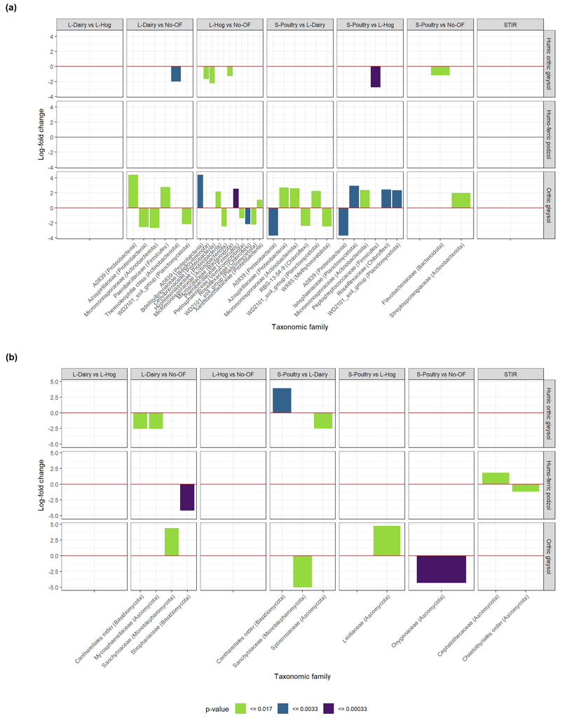

```r
ggarrange(p_16S, p_ITS,
          common.legend = TRUE, legend = "bottom",
          labels = c("(a)", "(b)"), ncol = 1)
```

```r
ggsave(file.path(article_fig_path, "fig5.pdf"),
       width = 12, height = 15, units = "in")
```